# team

Connor Hergenreter & Danny Nguyen

April 17, 2019

# Updated commit - Connor Hergenreter & Danny Nguyen

# PART 1: Accident data

```r
acc <- read.csv("https://raw.githubusercontent.com/xdaiISU/ds202materials/master/hwlabs/fars2017/accident.csv", stringsAsFactors = FALSE)

per <- read.csv("https://raw.githubusercontent.com/xdaiISU/ds202materials/master/hwlabs/fars2017/person.csv", stringsAsFactors = FALSE)
```

```r
library(ggplot2)
library(dplyr)
library(tidyr)
library(readxl)
```

# Question 1

The following chart shows the amount of accidents that have occurred on each day. It shows that Satuday has the highest accident count at 5873. The “safest” day would be Wednesday at 4314 accidents.

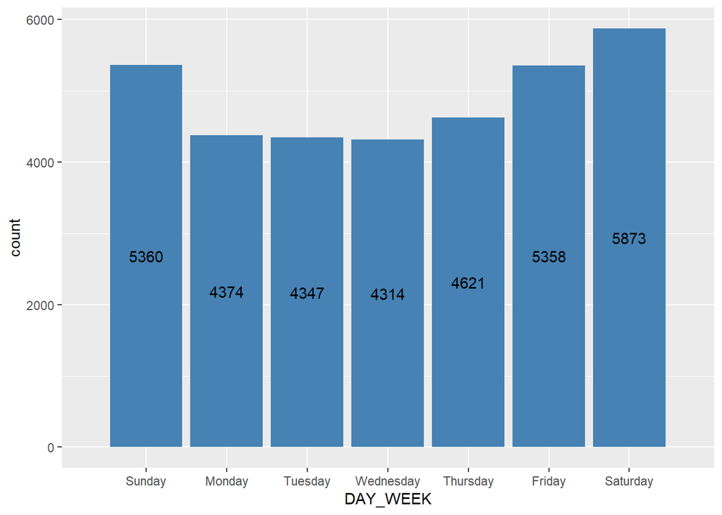

```r
ggplot(acc, aes(x=DAY_WEEK)) + geom_bar(stat="count", fill="steelblue") + geom_text(aes(label=..count..), stat="count",position=position_stack(0.5)) + scale_x_discrete(limits=c("Sunday","Monday","Tuesday","Wednesday","Thursday","Friday","Saturday"))
```

# Question 2

The chart below shows that the count of accidents by hour. The hour with the most amount of accidents is 6p.m. at 2000 and the hour with the least amount of accidents is 4a.m. at 813.

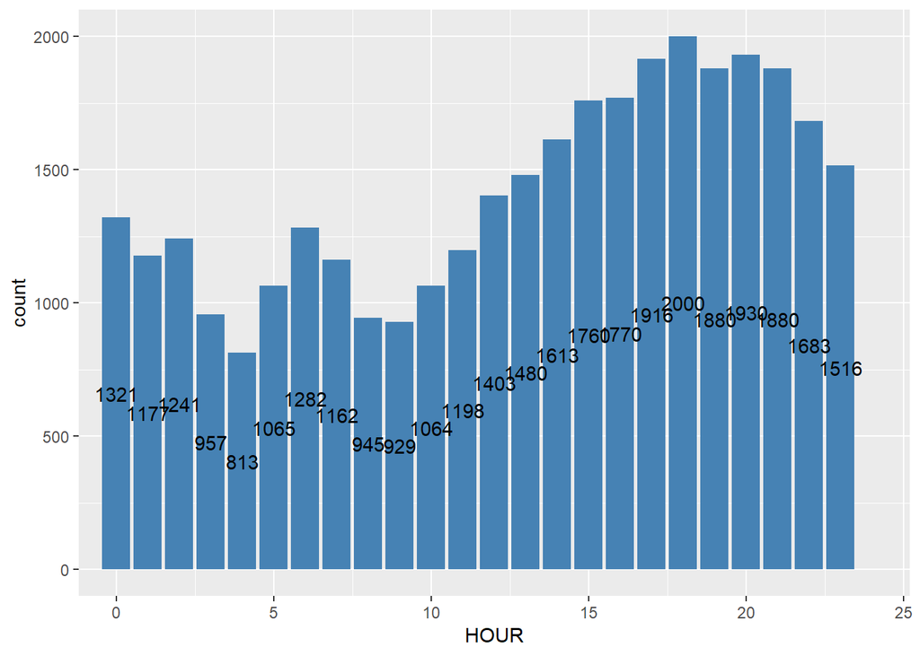

```r
ggplot(acc, aes(x=HOUR)) + geom_bar(stat="count", fill="steelblue") + geom_text(aes(label=..count..), stat="Count", position=position_stack(0.5)) + coord_cartesian(xlim=c(0,24))
```

# Question 3

The following chart shows the amount of drunk drivers per accident. The total count of accidents involving drunk drivers is 8769.

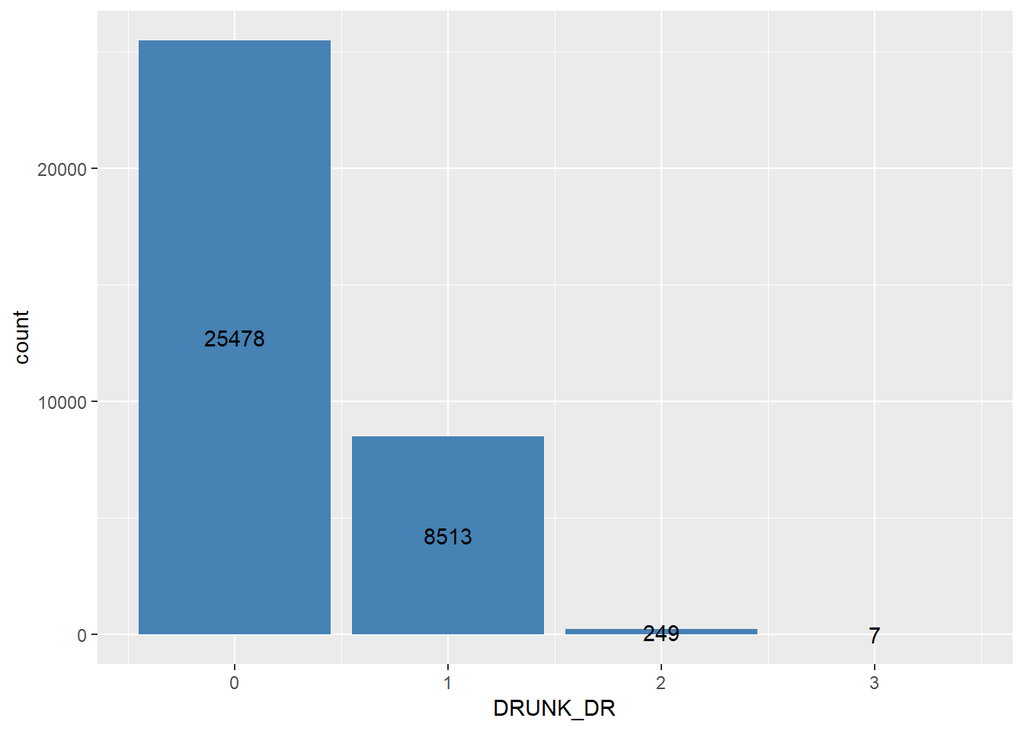

```r
ggplot(acc, aes(x=DRUNK_DR)) + geom_bar(stat="count", fill="steelblue") + geom_text(aes(label=..count..), stat="Count", position=position_stack(0.5))
```

# Part 2: Connecting data

# Question 1: Load the person table. Identify drivers (PER_TYP == 1, see fars manual) and subset on them.

```r
#load person table
per <- read.csv("https://raw.githubusercontent.com/xdaiISU/ds202materials/master/hwlabs/fars2017/person.csv", stringsAsFactors = FALSE)

#subset of drivers
drivers <- per[per$PER_TYP == 1, c(29)]
summary(drivers)
```

```
##    Min. 1st Qu.  Median    Mean 3rd Qu.    Max.
##       1       1       1       1       1       1
```

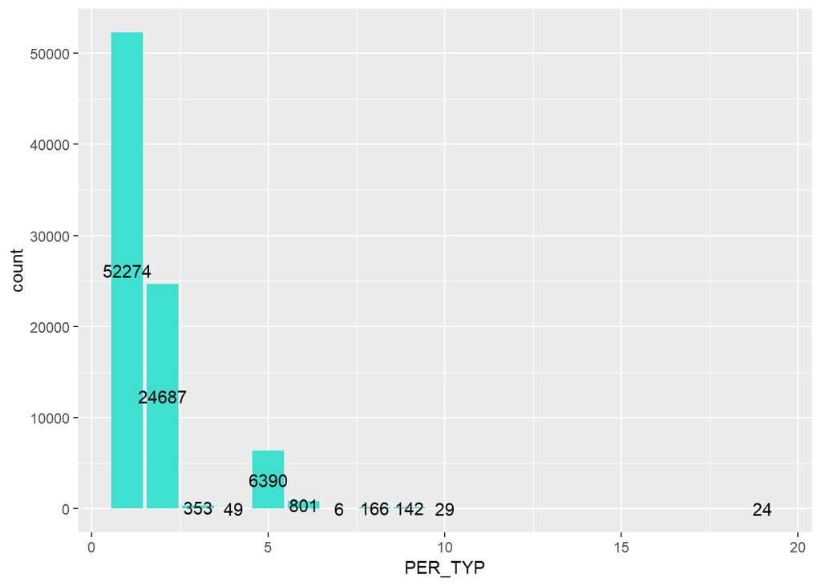

```r
#extra: visualization of the count of each PER_TYP.
ggplot(per, aes(x = PER_TYP)) + geom_bar(stat = "count", fill = "turquoise") + geom_text(aes(label = ..count..), stat = "count", position = position_stack(0.5))
```

# Question 2: Join accident and driver table (work out which variable(s) to use)

```r
#the inner_join will result in joining the two tables by automatically matching up the same variables from both tables which are ("STATE", "ST_CASE", "VE_FORMS", "COUNTY", "DAY", "MONTH", "HOUR", "MINUTE", "RUR_URB", "FUNC_SYS", "HARM_EV", "MAN_COLL", "SCH_BUS")
drivAcci <- inner_join(acc, per)
```

# Question 3: Tally the number of accidents by day of the week (DAY_WEEK), hour of the day (HOUR) and gender (SEX). Visualize the results!

```r
#total number of accidents based on Day of the Week, Hour of the Day, and Sex
sum(drivAcci$DAY_WEEK)
```

```
## [1] 351000
```

```r
sum(drivAcci$HOUR)
```

```
## [1] 1161947
```

```r
sum(drivAcci$SEX)
```

```
## [1] 124933
```

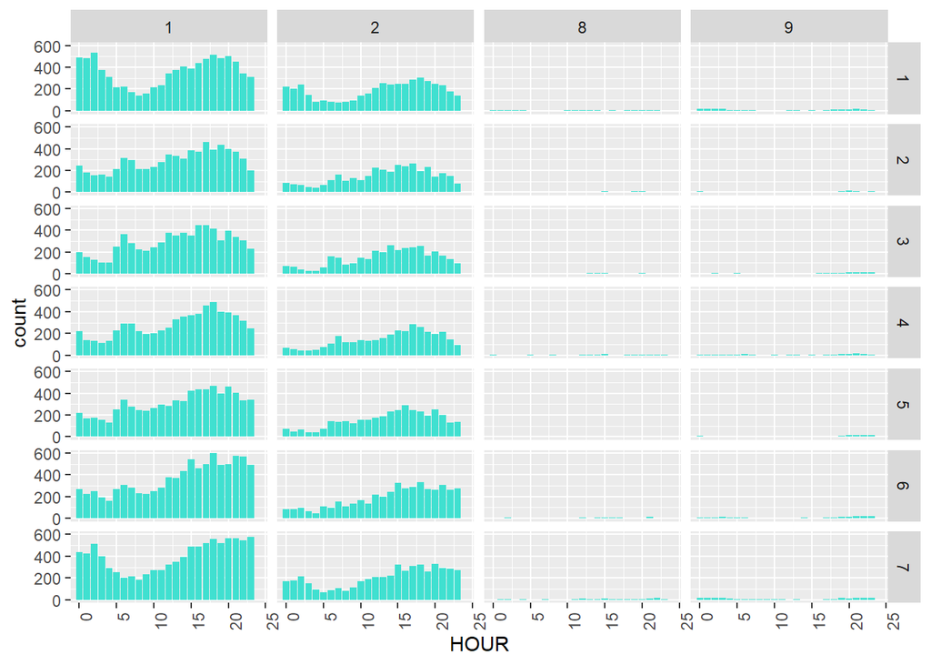

```r
#Facet Grid visual of Accidents for each hour for each day of the week and divided among the different sex classifications.

#The label code for gender report is 1 = male, 2 = female, 8 = not reported, and 9 = unknown

#The label code for day of the week is 1 = "Sunday", 2 = "Monday", 3 = "Tuesday", 4 = "Wednesday", 5 = "Thursday", 6 = "Friday", and  7 = "Saturday"

ggplot(drivAcci, aes(x = HOUR)) + geom_bar(stat = "count", fill = "turquoise") + theme(axis.text.x = element_text(angle = 90, hjust = 1)) + facet_grid(DAY_WEEK ~ SEX) + coord_cartesian(xlim = c(0, 24))
```

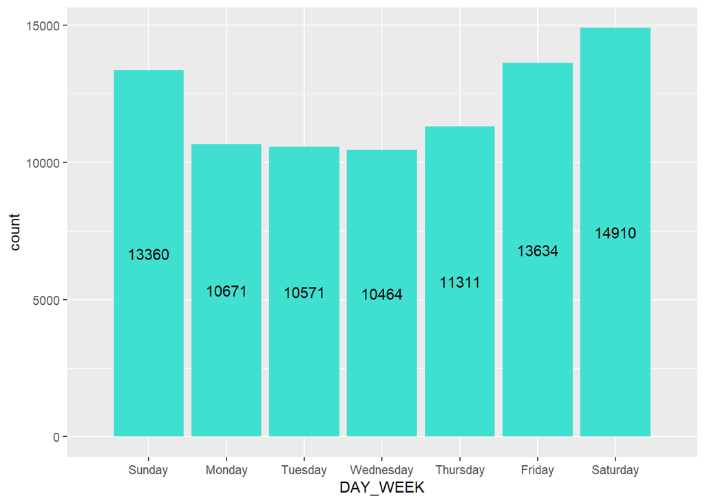

```r
#the three seperate visuals of accidents based on day of week, hour of day, and sex.
accWeek <- ggplot(drivAcci, aes(x = DAY_WEEK)) + geom_bar(stat = "count", fill = "turquoise") + geom_text(aes(label = ..count..), stat = "count", position = position_stack(0.5)) + scale_x_discrete(limits = c("Sunday","Monday","Tuesday","Wednesday","Thursday","Friday","Saturday"))

accHour <- ggplot(drivAcci, aes(x = HOUR)) + geom_bar(stat = "count", fill = "turquoise") + geom_text(aes(label = ..count..), stat = "count", position = position_stack(0.5)) + coord_cartesian(xlim = c(0, 24))

#The label code for gender report is 1 = male, 2 = female, 8 = not reported, and 9 = unknown
accSex <- ggplot(drivAcci, aes(x = SEX)) + geom_bar(stat = "count", fill = "turquoise") + geom_text(aes(label = ..count..), stat = "count", position = position_stack(0.5)) + facet_wrap(SEX ~ ., labeller = label_both)

accWeek #Number of accidents based on day of the week with data from the combined tables
```

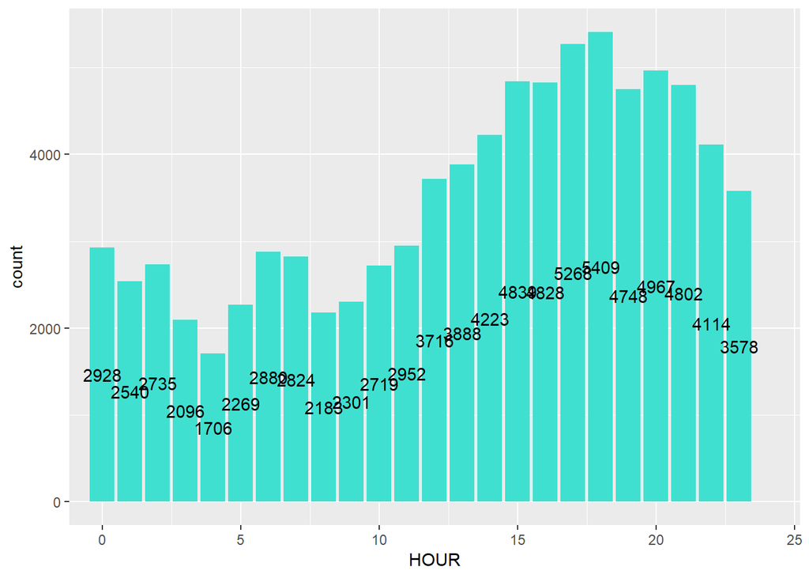

```r
accHour #Number of accidents based on hour of the day with data from the combined tables
```

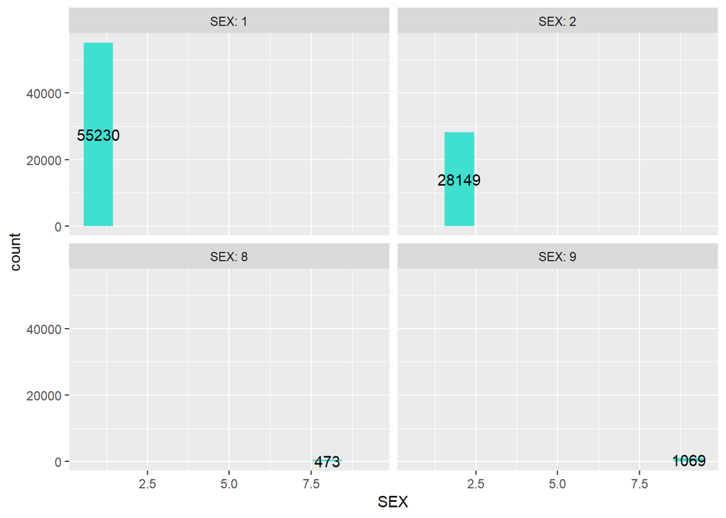

```r
#The label code for gender report is 1 = male, 2 = female, 8 = not reported, and 9 = unknown
accSex  #Number of accidents based on sex with data from the combined tables
```

# Part 3

# Question 1

```r
glcs <- read_xlsx("FRPP GLC United States.xlsx", skip=1)
```

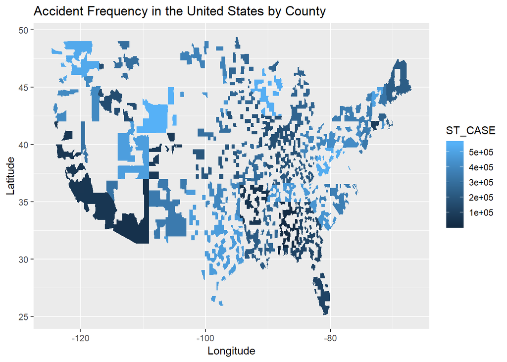

```r
counties <- map_data("county")
glcs$`State Code` <- as.numeric(glcs$`State Code`)
glcs$`County Code` <- as.numeric(glcs$`County Code`)
glcs$`City Code` <- as.numeric(glcs$`City Code`)
accGlcs <- left_join(acc, glcs, by = c("STATE" = "State Code", "COUNTY" = "County Code", "CITY" = "City Code"))

counties$region <- toupper(counties$region)
counties$subregion <- toupper(counties$subregion)
accident.map <- accGlcs %>% left_join(counties, by = c("State Name" = "region", "County Name" = "subregion"))

ggplot(accident.map, aes(x=long, y=lat, fill=ST_CASE)) + geom_polygon(aes(group=group)) + labs(title="Accident Frequency in the United States by County", x="Longitude", y="Latitude")
```

# Question 2

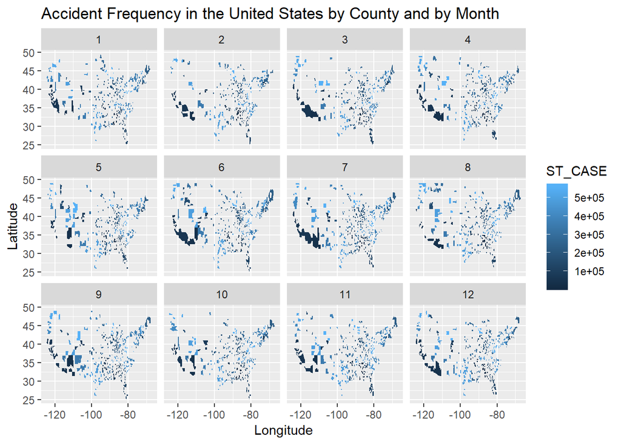

```r
ggplot(accident.map, aes(x=long, y=lat, fill=ST_CASE)) + geom_polygon(aes(group=group)) + labs(title="Accident Frequency in the United States by County and by Month", x="Longitude", y="Latitude") + facet_wrap(~MONTH)
```